# Análisis exploratorio de datos (EDA): Análisis espacio-temporal de la mortalidad por cánceres prioritarios en Colombia (2010–2024): una perspectiva jerárquica bayesiana

**Autor:** Miguel Ángel Pérez Vargas✉

## 0. Introducción

El presente proyecto aborda el análisis espacio-temporal de la mortalidad asociada con cánceres prioritarios en Colombia durante el periodo 2010–2024, con el propósito de estudiar la distribución geográfica del riesgo y su evolución a través del tiempo. Este tipo de análisis permite examinar la heterogeneidad de la mortalidad entre diferentes unidades territoriales e identificar patrones espaciales y temporales que pueden no ser evidentes al considerar únicamente los conteos observados.

El estudio de la mortalidad desde una perspectiva geográfica requiere considerar las diferencias existentes entre las poblaciones de cada territorio. En particular, la comparación directa del número de defunciones puede resultar insuficiente cuando las unidades geográficas presentan tamaños y estructuras poblacionales diferentes. Además, en áreas con poblaciones pequeñas, un número reducido de eventos puede generar estimaciones de riesgo altamente variables. Por esta razón, el proyecto contempla posteriormente la utilización de modelos jerárquicos bayesianos, los cuales permiten incorporar la estructura espacial y temporal de los datos y obtener estimaciones más estables del riesgo de mortalidad.

Como primera etapa del estudio, se realizará un Análisis Exploratorio de Datos (EDA) orientado a comprender la estructura y calidad de la información disponible, caracterizar la población registrada e identificar patrones demográficos, geográficos y temporales relevantes. Para esta exploración inicial se trabajará con los registros correspondientes a cáncer de estómago y cáncer de pulmón, seleccionados como una primera aproximación al conjunto de cánceres prioritarios contemplados en la investigación. Los resultados obtenidos permitirán establecer las decisiones de procesamiento y análisis necesarias para las etapas posteriores de modelamiento y representación cartográfica del riesgo.

:::{admonition} Nota Metodológica: Alcance y Composición de los Datos

:class: note

Para el desarrollo de este análisis se dispone de registros de mortalidad correspondientes a diferentes tipos de cáncer prioritarios en Colombia. La información abarca múltiples años y contiene características demográficas, temporales y geográficas asociadas con las defunciones registradas, lo que permite estudiar el fenómeno desde una perspectiva espacio-temporal.

En esta primera etapa del análisis exploratorio se utilizan dos conjuntos de datos:

- `ESTOMAGO2008_2024.sav`: registros asociados con mortalidad por cáncer de estómago.
- `PULMÓN2008_2024.sav`: registros asociados con mortalidad por cáncer de pulmón.

Ambos conjuntos se encuentran almacenados en formato `.sav`, correspondiente al formato de datos utilizado por IBM SPSS Statistics. Este formato permite conservar, además de las observaciones, información adicional asociada con la estructura de los datos, como nombres de variables, etiquetas descriptivas y etiquetas correspondientes a las categorías codificadas.

Aunque los archivos disponibles contienen registros correspondientes al periodo 2008–2024, el horizonte temporal establecido para el proyecto comprende los años **2010–2024**. Por esta razón, durante el proceso de preparación de los datos se verificará la cobertura temporal disponible y se realizará la delimitación correspondiente antes de desarrollar los análisis comparativos.

El EDA se orientará inicialmente a evaluar la estructura general de ambos conjuntos de datos, la presencia de valores faltantes o inconsistencias, las características demográficas de los registros y su distribución temporal y geográfica. Esta caracterización constituye un paso previo al cálculo de medidas epidemiológicas y al posterior desarrollo de modelos jerárquicos bayesianos para el análisis del riesgo de mortalidad.

:::

```python
from pathlib import Path
import sys

import pandas as pd
import numpy as np
import matplotlib.pyplot as plt
import seaborn as sns
import pyreadstat
import geopandas as gpd

from IPython.display import display, HTML

RUTA_PROYECTO = Path(r"C:\Users\USER\Desktop\Tesis")
RUTA_DATOS = RUTA_PROYECTO / "Data"
RUTA_DIRECTORIOS = RUTA_PROYECTO / "Directorios"
RUTA_SRC = RUTA_PROYECTO / "src"

if str(RUTA_SRC) not in sys.path:
    sys.path.append(str(RUTA_SRC))

from eda_toolkit import *

pd.set_option("display.max_columns", None)
pd.set_option("display.max_rows", 100)
pd.set_option("display.float_format", lambda x: f"{x:,.2f}")

sns.set_theme(style="whitegrid")

if "df_estomago" not in globals():
    df_estomago, meta_estomago = pyreadstat.read_sav(
        RUTA_DATOS / "ESTOMAGO2008_2024.sav"
    )
    print("Dataset de cáncer de estómago cargado correctamente.")
else:
    print("Dataset de cáncer de estómago ya disponible en memoria.")

if "df_pulmon" not in globals():
    df_pulmon, meta_pulmon = pyreadstat.read_sav(
        RUTA_DATOS / "PULMÓN2008_2024.sav"
    )
    print("Dataset de cáncer de pulmón cargado correctamente.")
else:
    print("Dataset de cáncer de pulmón ya disponible en memoria.")
    print("Dataset de cáncer de pulmón ya disponible en memoria.")
```

```
Dataset de cáncer de estómago cargado correctamente.
Dataset de cáncer de pulmón cargado correctamente.
```

## 1. Caracterización inicial de los datos

Se realiza una primera caracterización de los registros de mortalidad por cáncer de estómago y cáncer de pulmón con el propósito de establecer la estructura y cobertura de la información disponible. Para ambos conjuntos se examinan el número de registros, las variables disponibles, sus tipos de datos y la información descriptiva almacenada en las etiquetas originales de SPSS.

Esta revisión permitirá determinar el grado de comparabilidad entre ambos conjuntos e identificar las variables demográficas, temporales y geográficas que podrán incorporarse en las etapas posteriores del análisis.

### 1.1 Estructura de los conjuntos de datos

Los conjuntos correspondientes a cáncer de estómago y cáncer de pulmón contienen **85.128** y **74.922** registros, respectivamente, con un total de **61 variables** en ambos casos. A continuación, se examina la estructura de estas variables y su correspondencia entre los dos conjuntos de datos.

```python
columnas = pd.DataFrame({
    "Variable estómago": df_estomago.columns,
    "Variable pulmón": df_pulmon.columns
})

styled_columnas = columnas.style.hide(axis="index").set_table_styles([
    {
        "selector": "",
        "props": [
            ("margin-left", "auto"),
            ("margin-right", "auto"),
            ("width", "auto"),
            ("border-collapse", "collapse")
        ]
    },
    {
        "selector": "th",
        "props": [
            ("text-align", "center"),
            ("background-color", "#f2f2f2"),
            ("color", "black"),
            ("font-weight", "bold"),
            ("border", "1px solid black"),
            ("padding", "10px")
        ]
    },
    {
        "selector": "td",
        "props": [
            ("text-align", "center"),
            ("border", "1px solid black"),
            ("padding", "10px")
        ]
    }
])

styled_columnas = styled_columnas.set_properties(
    subset=["Variable estómago", "Variable pulmón"],
    **{"text-align": "left"}
)

display(
    HTML(
        "<div style='text-align: center; width: 100%;'>"
        + styled_columnas.to_html()
        + "</div>"
    )
)
```

| Variable estómago | Variable pulmón |
| --- | --- |
| COD_DPTO | COD_DPTO |
| COD_MUNIC | COD_MUNIC |
| A_DEFUN | A_DEFUN |
| ANO | ANO |
| MES | MES |
| SEXO | SEXO |
| GRU_ED1 | GRU_ED1 |
| EST_CIVIL | EST_CIVIL |
| CODPTORE | CODPTORE |
| CODMUNRE | CODMUNRE |
| SIT_DEFUN | SIT_DEFUN |
| C_BAS1 | C_BAS1 |
| CONS_EXP | CONS_EXP |
| CAU_HOMOL | CAU_HOMOL |
| GRU_ED2 | GRU_ED2 |
| AREA_RES | AREA_RES |
| perman_mun | perman_mun |
| PMAN_MUER | PMAN_MUER |
| tiem_per | tiem_per |
| COD_INST | COD_INST |
| NOM_INST | NOM_INST |
| TIPO_DEFUN | TIPO_DEFUN |
| NIVEL_EDU | NIVEL_EDU |
| CODPRES | CODPRES |
| SEG_SOCIAL | SEG_SOCIAL |
| EST_CIVM | EST_CIVM |
| MAN_MUER | MAN_MUER |
| CODOCUR | CODOCUR |
| CODMUNOC | CODMUNOC |
| C_MUERTE | C_MUERTE |
| ASIS_MED | ASIS_MED |
| C_DIR1 | C_DIR1 |
| C_ANT1 | C_ANT1 |
| C_ANT2 | C_ANT2 |
| C_ANT3 | C_ANT3 |
| C_PAT1 | C_PAT1 |
| C_MCM1 | C_MCM1 |
| CAUSA_666 | CAUSA_666 |
| OTRSITIODE | OTRSITIODE |
| HORA | HORA |
| SIMUERTEPO | SIMUERTEPO |
| OCUPACION | OCUPACION |
| IDPERTET | IDPERTET |
| IDADMISALUD | IDADMISALUD |
| IDCLASADMI | IDCLASADMI |
| C_MUERTEB | C_MUERTEB |
| C_MUERTEC | C_MUERTEC |
| C_MUERTED | C_MUERTED |
| C_MUERTEE | C_MUERTEE |
| C_DIR12 | C_DIR12 |
| C_ANT12 | C_ANT12 |
| C_ANT22 | C_ANT22 |
| C_ANT32 | C_ANT32 |
| C_PAT2 | C_PAT2 |
| IDPROFCER | IDPROFCER |
| CAUSA_667 | CAUSA_667 |
| P_PMAN_IRIS | P_PMAN_IRIS |
| CAUSA_MULT | CAUSA_MULT |
| TIPOFORMULARIO | TIPOFORMULARIO |
| C_MUERTEF | C_MUERTEF |
| C_MUERTEG | C_MUERTEG |

La coincidencia en el número y la denominación de las variables sugiere una estructura común entre ambos conjuntos de datos. Para confirmar esta correspondencia, se evalúan adicionalmente el orden y los tipos de datos de las variables.

```python
comparacion_estructura = pd.DataFrame({
    "Criterio": [
        "Mismo número de variables",
        "Mismos nombres de variables",
        "Mismo orden de variables",
        "Mismos tipos de datos"
    ],
    "Resultado": [
        df_estomago.shape[1] == df_pulmon.shape[1],
        set(df_estomago.columns) == set(df_pulmon.columns),
        df_estomago.columns.equals(df_pulmon.columns),
        df_estomago.dtypes.equals(df_pulmon.dtypes)
    ]
})

comparacion_estructura["Resultado"] = comparacion_estructura["Resultado"].map({
    True: "Sí",
    False: "No"
})

styled_estructura = comparacion_estructura.style.hide(axis="index").set_table_styles([
    {
        "selector": "",
        "props": [
            ("margin-left", "auto"),
            ("margin-right", "auto"),
            ("width", "auto"),
            ("border-collapse", "collapse")
        ]
    },
    {
        "selector": "th",
        "props": [
            ("text-align", "center"),
            ("background-color", "#f2f2f2"),
            ("color", "black"),
            ("font-weight", "bold"),
            ("border", "1px solid black"),
            ("padding", "10px")
        ]
    },
    {
        "selector": "td",
        "props": [
            ("text-align", "center"),
            ("border", "1px solid black"),
            ("padding", "10px")
        ]
    }
])

styled_estructura = styled_estructura.set_properties(
    subset=["Criterio"],
    **{"text-align": "left"}
)

display(
    HTML(
        "<div style='text-align: center; width: 100%;'>"
        + styled_estructura.to_html()
        + "</div>"
    )
)
```

| Criterio | Resultado |
| --- | --- |
| Mismo número de variables | Sí |
| Mismos nombres de variables | Sí |
| Mismo orden de variables | Sí |
| Mismos tipos de datos | Sí |

La comparación confirma que ambos conjuntos presentan una estructura completamente equivalente: coinciden en el número, nombre, orden y tipo de las variables. Esta correspondencia permite aplicar un esquema común de procesamiento y análisis para ambos tipos de cáncer, facilitando posteriormente su comparación bajo criterios metodológicos consistentes.

### 1.2 Calidad e integridad de los datos

Una vez establecida la equivalencia estructural entre ambos conjuntos, se evalúa la calidad de la información disponible mediante la identificación de registros duplicados y valores ausentes. Esta revisión permite reconocer posibles problemas de integridad antes de realizar transformaciones o analizar los patrones demográficos, temporales y geográficos de la mortalidad.

Inicialmente, se cuantifica la presencia de registros completamente duplicados en cada conjunto de datos.

```python
resumen_duplicados = pd.DataFrame({
    "Conjunto de datos": ["Cáncer de estómago", "Cáncer de pulmón"],
    "Registros totales": [len(df_estomago), len(df_pulmon)],
    "Registros duplicados": [
        df_estomago.duplicated().sum(),
        df_pulmon.duplicated().sum()
    ]
})

resumen_duplicados["Porcentaje (%)"] = (
    resumen_duplicados["Registros duplicados"]
    / resumen_duplicados["Registros totales"]
    * 100
)

format_dict_duplicados = {
    "Registros totales": lambda x: f"{x:,.0f}",
    "Registros duplicados": lambda x: f"{x:,.0f}",
    "Porcentaje (%)": lambda x: f"{x:.2f}"
}

styled_duplicados = resumen_duplicados.style.hide(axis="index").set_table_styles([
    {
        "selector": "",
        "props": [
            ("margin-left", "auto"),
            ("margin-right", "auto"),
            ("width", "auto"),
            ("border-collapse", "collapse")
        ]
    },
    {
        "selector": "th",
        "props": [
            ("text-align", "center"),
            ("background-color", "#f2f2f2"),
            ("color", "black"),
            ("font-weight", "bold"),
            ("border", "1px solid black"),
            ("padding", "10px")
        ]
    },
    {
        "selector": "td",
        "props": [
            ("text-align", "center"),
            ("border", "1px solid black"),
            ("padding", "10px")
        ]
    }
])

styled_duplicados = styled_duplicados.set_properties(
    subset=["Conjunto de datos"],
    **{"text-align": "left"}
)

styled_duplicados = styled_duplicados.format(format_dict_duplicados)

display(
    HTML(
        "<div style='text-align: center; width: 100%;'>"
        + styled_duplicados.to_html()
        + "</div>"
    )
)
```

| Conjunto de datos | Registros totales | Registros duplicados | Porcentaje (%) |
| --- | --- | --- | --- |
| Cáncer de estómago | 85,128 | 2 | 0.00 |
| Cáncer de pulmón | 74,922 | 2 | 0.00 |

En ambos conjuntos se encontraron únicamente **2 registros completamente duplicados**, por lo que su presencia es mínima frente al tamaño total de los datos. Por el momento, estos registros se mantendrán sin modificaciones, ya que no se dispone de un identificador único que permita determinar si corresponden realmente a observaciones repetidas.

El siguiente aspecto por revisar corresponde a los valores faltantes. Para ello, se calcula la cantidad y el porcentaje de datos ausentes en cada variable, comparando su comportamiento entre los registros de cáncer de estómago y cáncer de pulmón.

```python
faltantes_estomago = pd.DataFrame({
    "Variable": df_estomago.columns,
    "Faltantes estómago": df_estomago.isna().sum().values,
    "% estómago": (df_estomago.isna().mean().values * 100)
})

faltantes_pulmon = pd.DataFrame({
    "Variable": df_pulmon.columns,
    "Faltantes pulmón": df_pulmon.isna().sum().values,
    "% pulmón": (df_pulmon.isna().mean().values * 100)
})

resumen_faltantes = faltantes_estomago.merge(
    faltantes_pulmon,
    on="Variable"
)

resumen_faltantes = resumen_faltantes[
    (resumen_faltantes["Faltantes estómago"] > 0) |
    (resumen_faltantes["Faltantes pulmón"] > 0)
].sort_values(
    by=["% estómago", "% pulmón"],
    ascending=False
)

format_dict_faltantes = {
    "Faltantes estómago": lambda x: f"{x:,.0f}",
    "% estómago": lambda x: f"{x:.2f}",
    "Faltantes pulmón": lambda x: f"{x:,.0f}",
    "% pulmón": lambda x: f"{x:.2f}"
}

styled_faltantes = resumen_faltantes.style.hide(axis="index").set_table_styles([
    {
        "selector": "",
        "props": [
            ("margin-left", "auto"),
            ("margin-right", "auto"),
            ("width", "auto"),
            ("border-collapse", "collapse")
        ]
    },
    {
        "selector": "th",
        "props": [
            ("text-align", "center"),
            ("background-color", "#f2f2f2"),
            ("color", "black"),
            ("font-weight", "bold"),
            ("border", "1px solid black"),
            ("padding", "10px")
        ]
    },
    {
        "selector": "td",
        "props": [
            ("text-align", "center"),
            ("border", "1px solid black"),
            ("padding", "10px")
        ]
    }
])

styled_faltantes = styled_faltantes.set_properties(
    subset=["Variable"],
    **{"text-align": "left"}
)

styled_faltantes = styled_faltantes.format(format_dict_faltantes)

display(
    HTML(
        "<div style='text-align: center; width: 100%;'>"
        + styled_faltantes.to_html()
        + "</div>"
    )
)
```

| Variable | Faltantes estómago | % estómago | Faltantes pulmón | % pulmón |
| --- | --- | --- | --- | --- |
| tiem_per | 85,128 | 100.00 | 74,922 | 100.00 |
| MAN_MUER | 85,128 | 100.00 | 74,922 | 100.00 |
| C_MUERTEG | 85,128 | 100.00 | 74,922 | 100.00 |
| EST_CIVM | 85,128 | 100.00 | 74,918 | 99.99 |
| CODOCUR | 85,118 | 99.99 | 74,916 | 99.99 |
| CODMUNOC | 85,118 | 99.99 | 74,916 | 99.99 |
| C_MUERTEF | 85,097 | 99.96 | 74,899 | 99.97 |
| C_MUERTE | 84,746 | 99.55 | 74,559 | 99.52 |
| C_MUERTEE | 84,504 | 99.27 | 74,221 | 99.06 |
| C_MUERTEC | 77,293 | 90.80 | 67,386 | 89.94 |
| TIPOFORMULARIO | 69,281 | 81.38 | 60,739 | 81.07 |
| P_PMAN_IRIS | 53,276 | 62.58 | 47,253 | 63.07 |
| C_MUERTED | 52,821 | 62.05 | 49,400 | 65.94 |
| CAUSA_667 | 47,937 | 56.31 | 42,520 | 56.75 |
| CAUSA_666 | 37,191 | 43.69 | 32,402 | 43.25 |
| PMAN_MUER | 31,852 | 37.42 | 27,669 | 36.93 |
| C_MUERTEB | 17,204 | 20.21 | 13,208 | 17.63 |
| CODPRES | 9,152 | 10.75 | 7,890 | 10.53 |
| IDADMISALUD | 7,932 | 9.32 | 7,006 | 9.35 |
| HORA | 207 | 0.24 | 144 | 0.19 |
| AREA_RES | 85 | 0.10 | 92 | 0.12 |
| CODPTORE | 50 | 0.06 | 45 | 0.06 |
| CODMUNRE | 50 | 0.06 | 45 | 0.06 |

La presencia de valores faltantes se concentra en un grupo específico de variables y presenta un comportamiento similar en ambos tipos de cáncer. Algunas variables se encuentran completamente vacías o presentan porcentajes elevados de ausencia, mientras que otras conservan información para prácticamente la totalidad de los registros.

Estas diferencias hacen necesario revisar posteriormente el periodo de disponibilidad y la función de las variables con mayor proporción de datos faltantes, ya que su ausencia puede estar relacionada con cambios en la estructura de los registros a lo largo de los años y no necesariamente con una pérdida de información.

### 1.3 Cobertura temporal de los registros

Los archivos disponibles abarcan un periodo más amplio que el definido para el estudio. Por esta razón, se revisa inicialmente la distribución anual de los registros con el fin de comprobar la cobertura temporal de ambos conjuntos e identificar posibles diferencias en la cantidad de información disponible entre años.

```python
comparacion_anios = pd.DataFrame({
    "Variable": ["A_DEFUN", "ANO"],
    "Mínimo estómago": [
        df_estomago["A_DEFUN"].min(),
        df_estomago["ANO"].min()
    ],
    "Máximo estómago": [
        df_estomago["A_DEFUN"].max(),
        df_estomago["ANO"].max()
    ],
    "Valores únicos estómago": [
        df_estomago["A_DEFUN"].nunique(),
        df_estomago["ANO"].nunique()
    ],
    "Mínimo pulmón": [
        df_pulmon["A_DEFUN"].min(),
        df_pulmon["ANO"].min()
    ],
    "Máximo pulmón": [
        df_pulmon["A_DEFUN"].max(),
        df_pulmon["ANO"].max()
    ],
    "Valores únicos pulmón": [
        df_pulmon["A_DEFUN"].nunique(),
        df_pulmon["ANO"].nunique()
    ]
})

styled_anios = comparacion_anios.style.hide(axis="index").set_table_styles([
    {
        "selector": "",
        "props": [
            ("margin-left", "auto"),
            ("margin-right", "auto"),
            ("width", "auto"),
            ("border-collapse", "collapse")
        ]
    },
    {
        "selector": "th",
        "props": [
            ("text-align", "center"),
            ("background-color", "#f2f2f2"),
            ("color", "black"),
            ("font-weight", "bold"),
            ("border", "1px solid black"),
            ("padding", "10px")
        ]
    },
    {
        "selector": "td",
        "props": [
            ("text-align", "center"),
            ("border", "1px solid black"),
            ("padding", "10px")
        ]
    }
])

styled_anios = styled_anios.set_properties(
    subset=["Variable"],
    **{"text-align": "left"}
)

styled_anios = styled_anios.format(precision=0)

display(
    HTML(
        "<div style='text-align: center; width: 100%;'>"
        + styled_anios.to_html()
        + "</div>"
    )
)
```

| Variable | Mínimo estómago | Máximo estómago | Valores únicos estómago | Mínimo pulmón | Máximo pulmón | Valores únicos pulmón |
| --- | --- | --- | --- | --- | --- | --- |
| A_DEFUN | 1 | 9.0 | 7 | 1 | 3.0 | 6 |
| ANO | 2008 | 2024 | 17 | 2008 | 2024 | 17 |

La variable `ANO` presenta una cobertura completa del periodo **2008–2024** en ambos conjuntos de datos, con **17 años distintos**, por lo que se adopta como referencia temporal para el análisis. Por su parte, `A_DEFUN` corresponde a una variable categórica codificada y no será utilizada para representar el año de ocurrencia de las defunciones.

Una vez identificada la variable temporal, se examina la cantidad de registros disponibles para cada año. Esta distribución permite observar la continuidad de la información a lo largo del periodo y detectar posibles cambios en el volumen de registros antes de delimitar el intervalo definitivo de análisis.

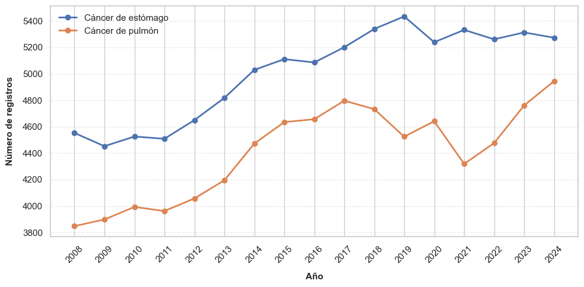

```python
registros_anuales = pd.concat([
    df_estomago.groupby("ANO").size().rename("Cáncer de estómago"),
    df_pulmon.groupby("ANO").size().rename("Cáncer de pulmón")
], axis=1).reset_index()

fig, ax = plt.subplots(figsize=(10, 5))

ax.plot(
    registros_anuales["ANO"],
    registros_anuales["Cáncer de estómago"],
    marker="o",
    linewidth=2,
    label="Cáncer de estómago"
)

ax.plot(
    registros_anuales["ANO"],
    registros_anuales["Cáncer de pulmón"],
    marker="o",
    linewidth=2,
    label="Cáncer de pulmón"
)

ax.set_xlabel("Año", fontsize=11, fontweight="bold", labelpad=10)
ax.set_ylabel("Número de registros", fontsize=11, fontweight="bold", labelpad=10)
ax.set_xticks(registros_anuales["ANO"].astype(int))
ax.tick_params(axis="x", rotation=45)
ax.legend(frameon=False)
ax.yaxis.grid(True, linestyle="--", alpha=0.4)

for spine in ax.spines.values():
    spine.set_visible(True)

plt.tight_layout()
plt.show()
```

Los registros presentan continuidad a lo largo de todo el periodo **2008–2024**, sin años ausentes en ninguno de los dos conjuntos. En términos generales, se observa un aumento en el número de registros durante el periodo analizado, aunque con variaciones interanuales más marcadas para el cáncer de pulmón.

El cáncer de estómago mantiene un mayor número de registros durante todos los años y muestra un comportamiento relativamente estable a partir de 2015. Por su parte, el cáncer de pulmón presenta mayores fluctuaciones, entre las que destaca una disminución en 2021 seguida de un incremento progresivo hasta alcanzar su mayor número de registros en 2024.

Dado que el periodo definido para la investigación corresponde a **2010–2024**, los registros de 2008 y 2009 serán excluidos de los análisis posteriores.

```python
df_estomago_eda = df_estomago[
    df_estomago["ANO"].between(2010, 2024)
].copy()

df_pulmon_eda = df_pulmon[
    df_pulmon["ANO"].between(2010, 2024)
].copy()
```

```python
resumen_periodo = pd.DataFrame({
    "Conjunto de datos": ["Cáncer de estómago", "Cáncer de pulmón"],
    "Registros originales": [len(df_estomago), len(df_pulmon)],
    "Registros 2010–2024": [len(df_estomago_eda), len(df_pulmon_eda)],
    "Registros excluidos": [
        len(df_estomago) - len(df_estomago_eda),
        len(df_pulmon) - len(df_pulmon_eda)
    ]
})

format_dict_periodo = {
    "Registros originales": lambda x: f"{x:,.0f}",
    "Registros 2010–2024": lambda x: f"{x:,.0f}",
    "Registros excluidos": lambda x: f"{x:,.0f}"
}

styled_periodo = resumen_periodo.style.hide(axis="index").set_table_styles([
    {
        "selector": "",
        "props": [
            ("margin-left", "auto"),
            ("margin-right", "auto"),
            ("width", "auto"),
            ("border-collapse", "collapse")
        ]
    },
    {
        "selector": "th",
        "props": [
            ("text-align", "center"),
            ("background-color", "#f2f2f2"),
            ("color", "black"),
            ("font-weight", "bold"),
            ("border", "1px solid black"),
            ("padding", "10px")
        ]
    },
    {
        "selector": "td",
        "props": [
            ("text-align", "center"),
            ("border", "1px solid black"),
            ("padding", "10px")
        ]
    }
])

styled_periodo = styled_periodo.set_properties(
    subset=["Conjunto de datos"],
    **{"text-align": "left"}
)

styled_periodo = styled_periodo.format(format_dict_periodo)

display(
    HTML(
        "<div style='text-align: center; width: 100%;'>"
        + styled_periodo.to_html()
        + "</div>"
    )
)
```

| Conjunto de datos | Registros originales | Registros 2010–2024 | Registros excluidos |
| --- | --- | --- | --- |
| Cáncer de estómago | 85,128 | 76,122 | 9,006 |
| Cáncer de pulmón | 74,922 | 67,174 | 7,748 |

La delimitación del periodo de estudio a **2010–2024** reduce los conjuntos a **76.122 registros de cáncer de estómago** y **67.174 registros de cáncer de pulmón**. En consecuencia, se excluyen **9.006** y **7.748** observaciones, respectivamente, correspondientes a los años 2008 y 2009.

A partir de este punto, los análisis se realizan exclusivamente sobre los registros comprendidos dentro del periodo definido para la investigación.

### 1.4 Disponibilidad temporal de las variables

La elevada proporción de valores faltantes observada en algunas variables puede estar relacionada con cambios en la información recopilada durante el periodo de estudio. Para evaluar esta posibilidad, se revisa la disponibilidad anual de las variables que presentan datos ausentes, identificando los años en los que contienen información registrada.

```python
variables_faltantes = resumen_faltantes["Variable"].tolist()

def disponibilidad_temporal(df, variables, cancer):
    resultados = []

    for variable in variables:
        datos_validos = df.loc[df[variable].notna(), ["ANO", variable]]

        resultados.append({
            "Variable": variable,
            "Cáncer": cancer,
            "Primer año con datos": datos_validos["ANO"].min() if not datos_validos.empty else np.nan,
            "Último año con datos": datos_validos["ANO"].max() if not datos_validos.empty else np.nan,
            "Disponibilidad (%)": df[variable].notna().mean() * 100
        })

    return pd.DataFrame(resultados)

disponibilidad = pd.concat([
    disponibilidad_temporal(
        df_estomago_eda,
        variables_faltantes,
        "Estómago"
    ),
    disponibilidad_temporal(
        df_pulmon_eda,
        variables_faltantes,
        "Pulmón"
    )
])

disponibilidad = disponibilidad.pivot(
    index="Variable",
    columns="Cáncer",
    values=["Primer año con datos", "Último año con datos", "Disponibilidad (%)"]
)

disponibilidad.columns = [
    f"{variable} {cancer.lower()}"
    for variable, cancer in disponibilidad.columns
]

disponibilidad = disponibilidad.reset_index()

columnas_anio = [
    columna for columna in disponibilidad.columns
    if "año" in columna
]

format_dict_disponibilidad = {
    columna: lambda x: "—" if pd.isna(x) else f"{x:.0f}"
    for columna in columnas_anio
}

format_dict_disponibilidad.update({
    columna: lambda x: f"{x:.2f}"
    for columna in disponibilidad.columns
    if "Disponibilidad" in columna
})

styled_disponibilidad = disponibilidad.style.hide(axis="index").set_table_styles([
    {
        "selector": "",
        "props": [
            ("margin-left", "auto"),
            ("margin-right", "auto"),
            ("width", "auto"),
            ("border-collapse", "collapse")
        ]
    },
    {
        "selector": "th",
        "props": [
            ("text-align", "center"),
            ("background-color", "#f2f2f2"),
            ("color", "black"),
            ("font-weight", "bold"),
            ("border", "1px solid black"),
            ("padding", "10px")
        ]
    },
    {
        "selector": "td",
        "props": [
            ("text-align", "center"),
            ("border", "1px solid black"),
            ("padding", "10px")
        ]
    }
])

styled_disponibilidad = styled_disponibilidad.set_properties(
    subset=["Variable"],
    **{"text-align": "left"}
)

styled_disponibilidad = styled_disponibilidad.format(
    format_dict_disponibilidad
)

display(
    HTML(
        "<div style='text-align: center; width: 100%;'>"
        + styled_disponibilidad.to_html()
        + "</div>"
    )
)
```

| Variable | Primer año con datos estómago | Primer año con datos pulmón | Último año con datos estómago | Último año con datos pulmón | Disponibilidad (%) estómago | Disponibilidad (%) pulmón |
| --- | --- | --- | --- | --- | --- | --- |
| AREA_RES | 2010 | 2010 | 2024 | 2024 | 99.90 | 99.87 |
| CAUSA_666 | 2010 | 2010 | 2017 | 2017 | 51.14 | 51.76 |
| CAUSA_667 | 2018 | 2018 | 2024 | 2024 | 48.86 | 48.24 |
| CODMUNOC | 2019 | 2021 | 2024 | 2024 | 0.01 | 0.01 |
| CODMUNRE | 2010 | 2010 | 2024 | 2024 | 99.93 | 99.93 |
| CODOCUR | 2019 | 2021 | 2024 | 2024 | 0.01 | 0.01 |
| CODPRES | 2010 | 2010 | 2024 | 2024 | 93.81 | 94.04 |
| CODPTORE | 2010 | 2010 | 2024 | 2024 | 99.93 | 99.93 |
| C_MUERTE | 2010 | 2010 | 2024 | 2024 | 0.46 | 0.48 |
| C_MUERTEB | 2010 | 2010 | 2024 | 2024 | 79.65 | 82.45 |
| C_MUERTEC | 2010 | 2010 | 2024 | 2024 | 9.91 | 10.83 |
| C_MUERTED | 2010 | 2010 | 2024 | 2024 | 39.26 | 35.30 |
| C_MUERTEE | 2010 | 2010 | 2024 | 2024 | 0.45 | 0.56 |
| C_MUERTEF | 2023 | 2023 | 2024 | 2024 | 0.04 | 0.03 |
| C_MUERTEG | — | — | — | — | 0.00 | 0.00 |
| EST_CIVM | — | 2013 | — | 2022 | 0.00 | 0.01 |
| HORA | 2010 | 2010 | 2024 | 2024 | 99.73 | 99.79 |
| IDADMISALUD | 2010 | 2010 | 2023 | 2023 | 90.73 | 90.53 |
| MAN_MUER | — | — | — | — | 0.00 | 0.00 |
| PMAN_MUER | 2010 | 2010 | 2018 | 2018 | 58.16 | 58.81 |
| P_PMAN_IRIS | 2019 | 2019 | 2024 | 2024 | 41.84 | 41.19 |
| TIPOFORMULARIO | 2022 | 2022 | 2024 | 2024 | 20.82 | 21.11 |
| tiem_per | — | — | — | — | 0.00 | 0.00 |

La disponibilidad de las variables no es constante durante todo el periodo. Por ejemplo, `CAUSA_666` contiene información hasta 2017, mientras que `CAUSA_667` comienza a registrarse desde 2018. Otras variables, como `TIPOFORMULARIO` y `C_MUERTEF`, aparecen únicamente en los años más recientes.

También se encuentran variables con información disponible durante prácticamente todo el periodo, entre ellas `AREA_RES`, `CODMUNRE`, `CODPTORE` y `HORA`, todas con una disponibilidad cercana al **100 %**. Por otro lado, `C_MUERTEG`, `MAN_MUER` y `tiem_per` no presentan información en ninguno de los dos conjuntos.

Esto muestra que una parte de los valores faltantes está relacionada con los años en los que cada variable se encuentra disponible, por lo que su porcentaje de ausencia no puede interpretarse por sí solo como un problema de calidad de los datos.

## 2. Caracterización demográfica

En esta sección se examinan las principales características demográficas de los registros de mortalidad por cáncer de estómago y cáncer de pulmón durante el periodo 2010–2024. El análisis se centra principalmente en la distribución por sexo y edad, buscando identificar diferencias en la composición de ambos conjuntos y los grupos poblacionales en los que se concentra el mayor número de registros.

### 2.1 Distribución por sexo

La distribución por sexo permite comparar la composición de los registros de mortalidad por cáncer de estómago y cáncer de pulmón. Para facilitar la comparación entre conjuntos de diferente tamaño, se presentan tanto el número de registros como su participación porcentual dentro de cada tipo de cáncer.

```python
etiquetas_sexo = {
    1.0: "Masculino",
    2.0: "Femenino",
    3.0: "Indeterminado"
}

sexo_estomago = (
    df_estomago_eda["SEXO"]
    .map(etiquetas_sexo)
    .value_counts()
    .reindex(["Masculino", "Femenino", "Indeterminado"], fill_value=0)
)

sexo_pulmon = (
    df_pulmon_eda["SEXO"]
    .map(etiquetas_sexo)
    .value_counts()
    .reindex(["Masculino", "Femenino", "Indeterminado"], fill_value=0)
)

distribucion_sexo = pd.DataFrame({
    "Sexo": sexo_estomago.index,
    "Estómago": sexo_estomago.values,
    "% estómago": sexo_estomago.values / len(df_estomago_eda) * 100,
    "Pulmón": sexo_pulmon.values,
    "% pulmón": sexo_pulmon.values / len(df_pulmon_eda) * 100
})

format_dict_sexo = {
    "Estómago": lambda x: f"{x:,.0f}",
    "% estómago": lambda x: f"{x:.2f}",
    "Pulmón": lambda x: f"{x:,.0f}",
    "% pulmón": lambda x: f"{x:.2f}"
}

styled_sexo = distribucion_sexo.style.hide(axis="index").set_table_styles([
    {
        "selector": "",
        "props": [
            ("margin-left", "auto"),
            ("margin-right", "auto"),
            ("width", "auto"),
            ("border-collapse", "collapse")
        ]
    },
    {
        "selector": "th",
        "props": [
            ("text-align", "center"),
            ("background-color", "#f2f2f2"),
            ("color", "black"),
            ("font-weight", "bold"),
            ("border", "1px solid black"),
            ("padding", "10px")
        ]
    },
    {
        "selector": "td",
        "props": [
            ("text-align", "center"),
            ("border", "1px solid black"),
            ("padding", "10px")
        ]
    }
])

styled_sexo = styled_sexo.set_properties(
    subset=["Sexo"],
    **{"text-align": "left"}
)

styled_sexo = styled_sexo.format(format_dict_sexo)

display(
    HTML(
        "<div style='text-align: center; width: 100%;'>"
        + styled_sexo.to_html()
        + "</div>"
    )
)
```

| Sexo | Estómago | % estómago | Pulmón | % pulmón |
| --- | --- | --- | --- | --- |
| Masculino | 46,397 | 60.95 | 38,664 | 57.56 |
| Femenino | 29,724 | 39.05 | 28,510 | 42.44 |
| Indeterminado | 1 | 0.00 | 0 | 0.00 |

En ambos tipos de cáncer se observa una mayor proporción de registros correspondientes al sexo masculino. Esta diferencia es más marcada en el cáncer de estómago, donde los hombres representan el **60,95 %** de los registros, frente al **39,05 %** de las mujeres. En cáncer de pulmón, la distribución es ligeramente más equilibrada, aunque se mantiene el predominio masculino, con **57,56 %** frente a **42,44 %** de registros femeninos.

La categoría de sexo indeterminado presenta únicamente un registro en cáncer de estómago y ninguno en cáncer de pulmón, por lo que su participación dentro de los datos es prácticamente nula.

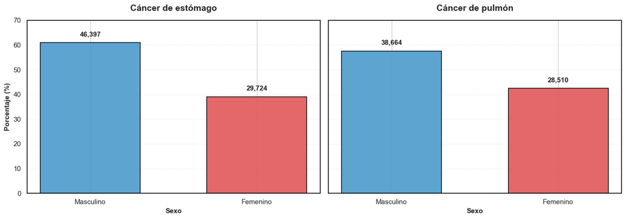

```python
level_mapping_sexo = {
    1.0: "Masculino",
    2.0: "Femenino"
}

fig, axes = plt.subplots(1, 2, figsize=(14, 5), sharey=True)

datasets = [
    (df_estomago_eda, "Cáncer de estómago"),
    (df_pulmon_eda, "Cáncer de pulmón")
]

colors = ["#4C9ACB", "#E15759"]

for ax, (df, title) in zip(axes, datasets):
    data = df[df["SEXO"].isin([1.0, 2.0])]["SEXO"]
    counts = data.value_counts().sort_index()
    percentages = counts / counts.sum() * 100
    labels = [level_mapping_sexo[value] for value in counts.index]

    bars = ax.bar(
        labels,
        percentages.values,
        color=colors,
        edgecolor="black",
        linewidth=1.2,
        width=0.6,
        alpha=0.9
    )

    for bar, count in zip(bars, counts.values):
        ax.text(
            bar.get_x() + bar.get_width() / 2,
            bar.get_height() + 2,
            f"{count:,}",
            ha="center",
            va="bottom",
            fontsize=11,
            fontweight="bold"
        )

    ax.set_title(
        title,
        fontsize=14,
        fontweight="bold",
        pad=15
    )

    ax.set_xlabel(
        "Sexo",
        fontsize=11,
        fontweight="bold"
    )

    ax.set_ylim(0, 70)

    ax.grid(
        axis="y",
        linestyle="--",
        alpha=0.25
    )

    ax.set_axisbelow(True)

    for spine in ax.spines.values():
        spine.set_visible(True)
        spine.set_color("black")
        spine.set_linewidth(1.2)

axes[0].set_ylabel(
    "Porcentaje (%)",
    fontsize=11,
    fontweight="bold"
)

plt.tight_layout()
plt.show()
```

### 2.2 Distribución por grupos de edad

Para este análisis se consideran las categorías de `GRU_ED1` cuya correspondencia etaria se encuentra definida en el directorio de variables. La categoría correspondiente a edad desconocida y los códigos sin una definición disponible no se incluyen en la comparación por grupos de edad.

```python
etiquetas_edad = {
    10.0: "15–19",
    11.0: "20–24",
    12.0: "25–29",
    13.0: "30–34",
    14.0: "35–39",
    15.0: "40–44",
    16.0: "45–49",
    17.0: "50–54",
    18.0: "55–59",
    19.0: "60–64",
    20.0: "65–69",
    21.0: "70–74",
    22.0: "75–79",
    23.0: "80–84",
    24.0: "85 y más"
}

orden_edad = list(etiquetas_edad.keys())
```

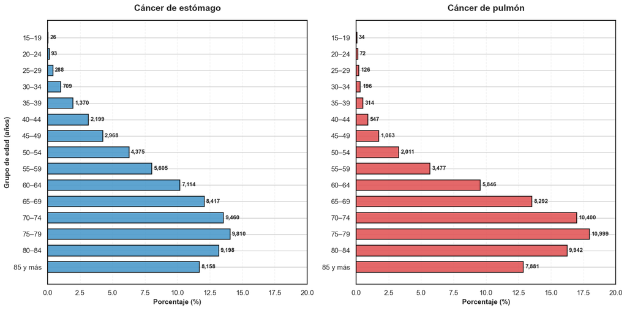

```python
fig, axes = plt.subplots(1, 2, figsize=(14, 7), sharex=True)

datasets = [
    (df_estomago_eda, "Cáncer de estómago", "#4C9ACB"),
    (df_pulmon_eda, "Cáncer de pulmón", "#E15759")
]

for ax, (df, title, color) in zip(axes, datasets):
    data = df[df["GRU_ED1"].isin(orden_edad)]["GRU_ED1"]
    counts = data.value_counts().reindex(orden_edad, fill_value=0)
    percentages = counts / counts.sum() * 100
    labels = [etiquetas_edad[value] for value in orden_edad]

    bars = ax.barh(
        labels,
        percentages.values,
        color=color,
        edgecolor="black",
        linewidth=1.2,
        height=0.65,
        alpha=0.9
    )

    for bar, count in zip(bars, counts.values):
        ax.text(
            bar.get_width() + 0.15,
            bar.get_y() + bar.get_height() / 2,
            f"{count:,}",
            va="center",
            fontsize=9,
            fontweight="bold"
        )

    ax.set_title(
        title,
        fontsize=14,
        fontweight="bold",
        pad=15
    )

    ax.set_xlabel(
        "Porcentaje (%)",
        fontsize=11,
        fontweight="bold"
    )

    ax.set_xlim(0, 20)

    ax.grid(
        axis="x",
        linestyle="--",
        alpha=0.25
    )

    ax.set_axisbelow(True)

    for spine in ax.spines.values():
        spine.set_visible(True)
        spine.set_color("black")
        spine.set_linewidth(1.2)

axes[0].set_ylabel(
    "Grupo de edad (años)",
    fontsize=11,
    fontweight="bold"
)

axes[0].invert_yaxis()
axes[1].invert_yaxis()

plt.tight_layout()
plt.show()
```

La distribución por edad muestra que, en ambos tipos de cáncer, los registros se concentran principalmente en los grupos de mayor edad. La participación aumenta progresivamente a partir de los 40 años y alcanza su mayor nivel entre los **75 y 79 años**.

En cáncer de pulmón esta concentración es más marcada, especialmente entre los **70 y 84 años**. En cáncer de estómago la distribución es algo más gradual y mantiene una participación importante en el grupo de **85 años y más**. Por el contrario, los registros correspondientes a edades jóvenes representan una proporción muy reducida en ambos conjuntos.

## 3. Análisis temporal

Una vez caracterizada la composición demográfica de los registros, se analiza su comportamiento a lo largo del periodo **2010–2024**. El objetivo es identificar cambios en la cantidad anual de defunciones registradas por cáncer de estómago y cáncer de pulmón, así como posibles diferencias en la evolución temporal de ambos tipos de cáncer.

### 3.1 Evolución anual de los registros

En primer lugar, se examina la cantidad de defunciones registradas en cada año del periodo de estudio. La comparación permite observar la evolución general de ambos tipos de cáncer e identificar años en los que se presentan cambios más marcados respecto al comportamiento observado durante el periodo.

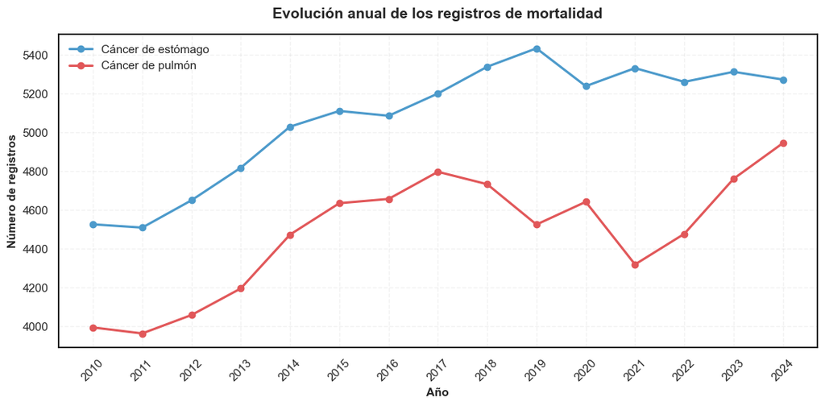

```python
registros_anuales_eda = pd.DataFrame({
    "Año": range(2010, 2025)
})

registros_anuales_eda["Cáncer de estómago"] = (
    df_estomago_eda["ANO"]
    .value_counts()
    .reindex(range(2010, 2025), fill_value=0)
    .values
)

registros_anuales_eda["Cáncer de pulmón"] = (
    df_pulmon_eda["ANO"]
    .value_counts()
    .reindex(range(2010, 2025), fill_value=0)
    .values
)

fig, ax = plt.subplots(figsize=(11, 5.5))

ax.plot(
    registros_anuales_eda["Año"],
    registros_anuales_eda["Cáncer de estómago"],
    marker="o",
    linewidth=2.2,
    markersize=6,
    label="Cáncer de estómago",
    color="#4C9ACB"
)

ax.plot(
    registros_anuales_eda["Año"],
    registros_anuales_eda["Cáncer de pulmón"],
    marker="o",
    linewidth=2.2,
    markersize=6,
    label="Cáncer de pulmón",
    color="#E15759"
)

ax.set_title(
    "Evolución anual de los registros de mortalidad",
    fontsize=14,
    fontweight="bold",
    pad=15
)

ax.set_xlabel(
    "Año",
    fontsize=11,
    fontweight="bold"
)

ax.set_ylabel(
    "Número de registros",
    fontsize=11,
    fontweight="bold"
)

ax.set_xticks(range(2010, 2025))
ax.tick_params(axis="x", rotation=45)

ax.grid(
    axis="both",
    linestyle="--",
    alpha=0.25
)

ax.set_axisbelow(True)
ax.legend(frameon=False)

for spine in ax.spines.values():
    spine.set_visible(True)
    spine.set_color("black")
    spine.set_linewidth(1.2)

plt.tight_layout()
plt.show()
```

Durante el periodo **2010–2024**, el cáncer de estómago mantiene un mayor número de registros que el cáncer de pulmón. En ambos casos se observa un crecimiento general durante los primeros años del periodo, aunque posteriormente las trayectorias presentan diferencias.

Los registros de cáncer de estómago aumentan de forma relativamente sostenida hasta 2019 y, a partir de ese año, se mantienen alrededor de valores similares con algunas variaciones. En cáncer de pulmón se observa un comportamiento más irregular, con disminuciones visibles en **2019 y 2021**, seguidas de un crecimiento durante los últimos años. Para 2024, el número de registros de pulmón alcanza su valor más alto dentro del periodo analizado y se aproxima al observado para cáncer de estómago.

### 3.2 Variación interanual

Para complementar la evolución de los conteos anuales, se calcula la variación porcentual respecto al año anterior. Este indicador permite identificar con mayor claridad los periodos en los que se presentaron los principales aumentos o disminuciones en el número de registros.

```python
variacion_interanual = registros_anuales_eda.copy()

variacion_interanual["Variación estómago (%)"] = (
    variacion_interanual["Cáncer de estómago"]
    .pct_change(fill_method=None)
    .mul(100)
)

variacion_interanual["Variación pulmón (%)"] = (
    variacion_interanual["Cáncer de pulmón"]
    .pct_change(fill_method=None)
    .mul(100)
)

variacion_interanual = variacion_interanual[
    ["Año", "Variación estómago (%)", "Variación pulmón (%)"]
].iloc[1:]

format_dict_variacion = {
    "Año": lambda x: f"{x:.0f}",
    "Variación estómago (%)": lambda x: f"{x:+.2f}",
    "Variación pulmón (%)": lambda x: f"{x:+.2f}"
}

styled_variacion = variacion_interanual.style.hide(axis="index").set_table_styles([
    {
        "selector": "",
        "props": [
            ("margin-left", "auto"),
            ("margin-right", "auto"),
            ("width", "auto"),
            ("border-collapse", "collapse")
        ]
    },
    {
        "selector": "th",
        "props": [
            ("text-align", "center"),
            ("background-color", "#f2f2f2"),
            ("color", "black"),
            ("font-weight", "bold"),
            ("border", "1px solid black"),
            ("padding", "10px")
        ]
    },
    {
        "selector": "td",
        "props": [
            ("text-align", "center"),
            ("border", "1px solid black"),
            ("padding", "10px")
        ]
    }
])

styled_variacion = styled_variacion.format(format_dict_variacion)

display(
    HTML(
        "<div style='text-align: center; width: 100%;'>"
        + styled_variacion.to_html()
        + "</div>"
    )
)
```

| Año | Variación estómago (%) | Variación pulmón (%) |
| --- | --- | --- |
| 2011 | -0.38 | -0.78 |
| 2012 | +3.13 | +2.40 |
| 2013 | +3.61 | +3.38 |
| 2014 | +4.40 | +6.63 |
| 2015 | +1.61 | +3.62 |
| 2016 | -0.49 | +0.47 |
| 2017 | +2.26 | +3.01 |
| 2018 | +2.65 | -1.33 |
| 2019 | +1.78 | -4.39 |
| 2020 | -3.59 | +2.59 |
| 2021 | +1.78 | -6.96 |
| 2022 | -1.33 | +3.66 |
| 2023 | +0.99 | +6.34 |
| 2024 | -0.75 | +3.86 |

La variación interanual muestra un comportamiento más estable para el cáncer de estómago, con cambios generalmente moderados durante el periodo. Su mayor incremento se presenta en **2014 (+4,40 %)**, mientras que la disminución más marcada ocurre en **2020 (-3,59 %)**.

En cáncer de pulmón las variaciones son mayores. Los principales incrementos se observan en **2014 (+6,63 %)** y **2023 (+6,34 %)**, mientras que las mayores disminuciones corresponden a **2019 (-4,39 %)** y, especialmente, **2021 (-6,96 %)**. Después de esta última caída, los registros aumentan durante tres años consecutivos entre 2022 y 2024.

## 4. Análisis geográfico

El componente geográfico permite examinar cómo se distribuyen los registros de mortalidad por cáncer de estómago y cáncer de pulmón en el territorio colombiano. Para este análisis se consideran las variables correspondientes al departamento y municipio de residencia, con el propósito de identificar diferencias en la distribución espacial de ambos tipos de cáncer durante el periodo 2010–2024.

Inicialmente se revisa la cobertura de los códigos geográficos disponibles y posteriormente se analiza la distribución de los registros a nivel departamental y municipal. Finalmente, esta información se representa mediante mapas para facilitar la identificación de patrones espaciales.

### 4.1 Cobertura geográfica de los registros

Antes de analizar la distribución espacial, se revisa la cobertura de la información geográfica disponible. Para ambos tipos de cáncer se identifica el número de departamentos y municipios presentes en los registros, así como la cantidad de observaciones que no cuentan con información sobre el lugar de residencia.

```python
resumen_geografico = pd.DataFrame({
    "Conjunto de datos": ["Cáncer de estómago", "Cáncer de pulmón"],
    "Departamentos": [
        df_estomago_eda["CODPTORE"].nunique(),
        df_pulmon_eda["CODPTORE"].nunique()
    ],
    "Municipios": [
        df_estomago_eda["CODMUNRE"].nunique(),
        df_pulmon_eda["CODMUNRE"].nunique()
    ],
    "Sin departamento": [
        df_estomago_eda["CODPTORE"].isna().sum(),
        df_pulmon_eda["CODPTORE"].isna().sum()
    ],
    "Sin municipio": [
        df_estomago_eda["CODMUNRE"].isna().sum(),
        df_pulmon_eda["CODMUNRE"].isna().sum()
    ]
})

format_dict_geografico = {
    "Departamentos": lambda x: f"{x:,.0f}",
    "Municipios": lambda x: f"{x:,.0f}",
    "Sin departamento": lambda x: f"{x:,.0f}",
    "Sin municipio": lambda x: f"{x:,.0f}"
}

styled_geografico = resumen_geografico.style.hide(axis="index").set_table_styles([
    {
        "selector": "",
        "props": [
            ("margin-left", "auto"),
            ("margin-right", "auto"),
            ("width", "auto"),
            ("border-collapse", "collapse")
        ]
    },
    {
        "selector": "th",
        "props": [
            ("text-align", "center"),
            ("background-color", "#f2f2f2"),
            ("color", "black"),
            ("font-weight", "bold"),
            ("border", "1px solid black"),
            ("padding", "10px")
        ]
    },
    {
        "selector": "td",
        "props": [
            ("text-align", "center"),
            ("border", "1px solid black"),
            ("padding", "10px")
        ]
    }
])

styled_geografico = styled_geografico.set_properties(
    subset=["Conjunto de datos"],
    **{"text-align": "left"}
)

styled_geografico = styled_geografico.format(format_dict_geografico)

display(
    HTML(
        "<div style='text-align: center; width: 100%;'>"
        + styled_geografico.to_html()
        + "</div>"
    )
)
```

| Conjunto de datos | Departamentos | Municipios | Sin departamento | Sin municipio |
| --- | --- | --- | --- | --- |
| Cáncer de estómago | 35 | 576 | 50 | 50 |
| Cáncer de pulmón | 35 | 568 | 45 | 45 |

La información geográfica presenta una cobertura prácticamente completa en ambos conjuntos. Únicamente **50 registros de cáncer de estómago** y **45 de cáncer de pulmón** no cuentan con información sobre el departamento y municipio de residencia, lo que representa menos del **0,1 %** de los registros analizados.

Se identifican **35 códigos departamentales** en ambos conjuntos, mientras que a nivel municipal se encuentran **576 municipios** para cáncer de estómago y **568 para cáncer de pulmón**. Antes de realizar la representación espacial, se revisarán los códigos departamentales para identificar posibles categorías adicionales a las divisiones territoriales utilizadas en el análisis.

### 4.2 Distribución departamental

```python
departamentos = {
    5.0: "Antioquia",
    8.0: "Atlántico",
    11.0: "Bogotá D.C.",
    13.0: "Bolívar",
    15.0: "Boyacá",
    17.0: "Caldas",
    18.0: "Caquetá",
    19.0: "Cauca",
    20.0: "Cesar",
    23.0: "Córdoba",
    25.0: "Cundinamarca",
    27.0: "Chocó",
    41.0: "Huila",
    44.0: "La Guajira",
    47.0: "Magdalena",
    50.0: "Meta",
    52.0: "Nariño",
    54.0: "Norte de Santander",
    63.0: "Quindío",
    66.0: "Risaralda",
    68.0: "Santander",
    70.0: "Sucre",
    73.0: "Tolima",
    76.0: "Valle del Cauca",
    81.0: "Arauca",
    85.0: "Casanare",
    86.0: "Putumayo",
    88.0: "San Andrés y Providencia",
    91.0: "Amazonas",
    94.0: "Guainía",
    95.0: "Guaviare",
    97.0: "Vaupés"
}
```

A partir de los códigos departamentales identificados, se comparan los departamentos con mayor número de registros para cada tipo de cáncer. Esta primera aproximación permite reconocer dónde se concentra la mayor cantidad de defunciones registradas antes de observar su distribución sobre el territorio nacional.

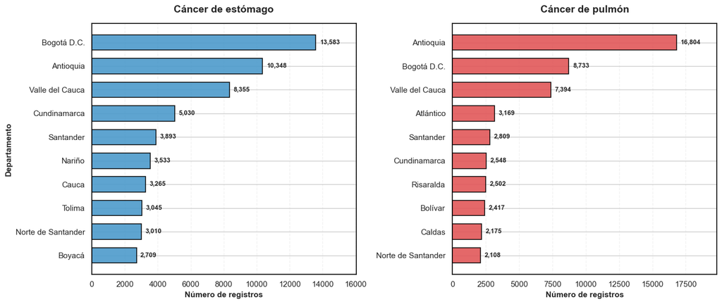

```python
top_n = 10

estomago_departamento = (
    df_estomago_eda[df_estomago_eda["CODPTORE"].isin(departamentos)]
    ["CODPTORE"]
    .map(departamentos)
    .value_counts()
    .head(top_n)
    .sort_values()
)

pulmon_departamento = (
    df_pulmon_eda[df_pulmon_eda["CODPTORE"].isin(departamentos)]
    ["CODPTORE"]
    .map(departamentos)
    .value_counts()
    .head(top_n)
    .sort_values()
)

fig, axes = plt.subplots(1, 2, figsize=(14, 6))

datasets = [
    (estomago_departamento, "Cáncer de estómago", "#4C9ACB"),
    (pulmon_departamento, "Cáncer de pulmón", "#E15759")
]

for ax, (data, title, color) in zip(axes, datasets):
    bars = ax.barh(
        data.index,
        data.values,
        color=color,
        edgecolor="black",
        linewidth=1.2,
        height=0.65,
        alpha=0.9
    )

    limite = data.max() * 1.18
    ax.set_xlim(0, limite)

    for bar, value in zip(bars, data.values):
        ax.text(
            bar.get_width() + limite * 0.015,
            bar.get_y() + bar.get_height() / 2,
            f"{value:,}",
            va="center",
            fontsize=9,
            fontweight="bold"
        )

    ax.set_title(
        title,
        fontsize=14,
        fontweight="bold",
        pad=15
    )

    ax.set_xlabel(
        "Número de registros",
        fontsize=11,
        fontweight="bold"
    )

    ax.grid(
        axis="x",
        linestyle="--",
        alpha=0.25
    )

    ax.set_axisbelow(True)

    for spine in ax.spines.values():
        spine.set_visible(True)
        spine.set_color("black")
        spine.set_linewidth(1.2)

axes[0].set_ylabel(
    "Departamento",
    fontsize=11,
    fontweight="bold"
)

plt.tight_layout()
plt.show()
```

La distribución departamental presenta diferencias entre ambos tipos de cáncer. En cáncer de estómago, **Bogotá D.C.** registra la mayor cantidad de casos, seguida por **Antioquia** y **Valle del Cauca**. También se observa una presencia importante de registros en Cundinamarca, Santander, Nariño y Cauca.

Para cáncer de pulmón, **Antioquia** presenta una concentración considerablemente mayor que el resto de los departamentos, con **16.804 registros**. Le siguen Bogotá D.C. y Valle del Cauca, mientras que Atlántico ocupa la cuarta posición.

Aunque algunos departamentos aparecen entre los primeros lugares para ambos tipos de cáncer, el orden y la magnitud de los registros presentan diferencias. Estos conteos corresponden a valores absolutos y, por tanto, no representan directamente diferencias en el riesgo de mortalidad entre departamentos.

### 4.3 Distribución espacial de los registros

La distribución departamental se representa espacialmente con el fin de observar la concentración de los registros sobre el territorio colombiano. Para cada tipo de cáncer se utiliza el número acumulado de defunciones registradas durante el periodo 2010–2024 a nivel departamental.

Estos mapas representan conteos absolutos y tienen un propósito exploratorio. Por esta razón, las diferencias observadas entre departamentos no deben interpretarse directamente como diferencias en el riesgo de mortalidad, ya que no se considera todavía el tamaño de la población de cada territorio.

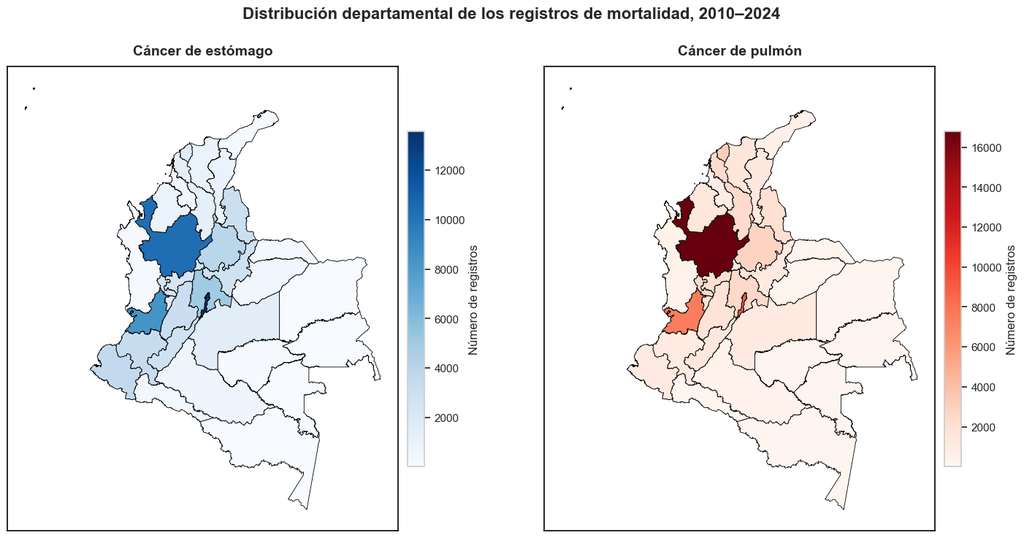

```python
fig, axes = plt.subplots(1, 2, figsize=(15, 8))

configuraciones = [
    ("Estómago", "Cáncer de estómago", "Blues"),
    ("Pulmón", "Cáncer de pulmón", "Reds")
]

for ax, (columna, titulo, cmap) in zip(axes, configuraciones):
    geo_departamentos.plot(
        column=columna,
        ax=ax,
        cmap=cmap,
        edgecolor="black",
        linewidth=0.6,
        legend=True,
        legend_kwds={
            "label": "Número de registros",
            "shrink": 0.70,
            "pad": 0.02
        }
    )

    ax.set_title(
        titulo,
        fontsize=14,
        fontweight="bold",
        pad=12
    )

    ax.set_xticks([])
    ax.set_yticks([])
    ax.set_xlabel("")
    ax.set_ylabel("")

    for spine in ax.spines.values():
        spine.set_visible(True)
        spine.set_color("black")
        spine.set_linewidth(1.2)

fig.suptitle(
    "Distribución departamental de los registros de mortalidad, 2010–2024",
    fontsize=16,
    fontweight="bold",
    y=0.97
)

plt.subplots_adjust(
    left=0.04,
    right=0.96,
    bottom=0.06,
    top=0.88,
    wspace=0.14
)

plt.show()
```

Los mapas muestran una distribución espacial diferente para los dos tipos de cáncer. En cáncer de estómago, los registros se concentran principalmente en **Bogotá D.C., Antioquia y Valle del Cauca**, aunque también se observan valores relativamente altos en varios departamentos de la región andina.

En cáncer de pulmón, la concentración es más marcada en **Antioquia**, que presenta el mayor número acumulado de registros durante el periodo analizado. Bogotá D.C. y Valle del Cauca también destacan, pero con una diferencia considerable frente a Antioquia.

En ambos mapas se observa una menor cantidad de registros en buena parte de los departamentos del oriente y sur del país. Sin embargo, esta distribución corresponde a **conteos absolutos de defunciones**, por lo que también está influenciada por el tamaño de la población de cada departamento. Por esta razón, los mapas permiten identificar la concentración espacial de los registros, pero no establecer todavía qué territorios presentan una mayor mortalidad relativa.

### 4.4 Mortalidad en relación con la población departamental

Los conteos analizados hasta ahora permiten identificar dónde se concentra el mayor número de defunciones, pero no consideran las diferencias en el tamaño de la población entre departamentos. Para realizar una comparación más adecuada entre territorios, se incorpora la población correspondiente a cada departamento y año durante el periodo 2010–2024.

A partir de esta información se calcularán tasas de mortalidad por cada 100.000 habitantes, relacionando el número de defunciones registradas con la población del mismo departamento y año.

#### 4.4.1 Evolución anual de las tasas de mortalidad

En primer lugar, se analiza el comportamiento de las tasas de mortalidad a nivel nacional durante el periodo 2010–2024. Para cada año, las defunciones registradas en los departamentos se relacionan con la población correspondiente, expresando el resultado como el número de muertes por cada 100.000 habitantes.

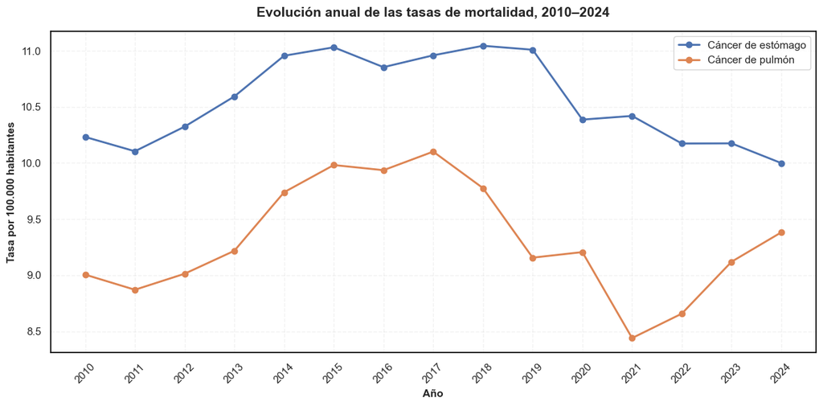

```python
tasas_nacionales = (
    mortalidad_dpto
    .groupby("ANO", as_index=False)
    .agg(
        Poblacion=("Poblacion", "sum"),
        Defunciones_estomago=("Defunciones_estomago", "sum"),
        Defunciones_pulmon=("Defunciones_pulmon", "sum")
    )
)

tasas_nacionales["Tasa_estomago"] = (
    tasas_nacionales["Defunciones_estomago"]
    / tasas_nacionales["Poblacion"]
    * 100000
)

tasas_nacionales["Tasa_pulmon"] = (
    tasas_nacionales["Defunciones_pulmon"]
    / tasas_nacionales["Poblacion"]
    * 100000
)

fig, ax = plt.subplots(figsize=(12, 6))

ax.plot(
    tasas_nacionales["ANO"],
    tasas_nacionales["Tasa_estomago"],
    marker="o",
    linewidth=2,
    label="Cáncer de estómago"
)

ax.plot(
    tasas_nacionales["ANO"],
    tasas_nacionales["Tasa_pulmon"],
    marker="o",
    linewidth=2,
    label="Cáncer de pulmón"
)

ax.set_title(
    "Evolución anual de las tasas de mortalidad, 2010–2024",
    fontsize=14,
    fontweight="bold",
    pad=15
)

ax.set_xlabel(
    "Año",
    fontsize=11,
    fontweight="bold"
)

ax.set_ylabel(
    "Tasa por 100.000 habitantes",
    fontsize=11,
    fontweight="bold"
)

ax.set_xticks(tasas_nacionales["ANO"])
ax.tick_params(axis="x", rotation=45)

ax.grid(
    axis="both",
    linestyle="--",
    alpha=0.25
)

ax.set_axisbelow(True)

for spine in ax.spines.values():
    spine.set_visible(True)
    spine.set_color("black")
    spine.set_linewidth(1.2)

ax.legend()

plt.tight_layout()
plt.show()
```

Al considerar el tamaño de la población, el cáncer de estómago mantiene tasas de mortalidad superiores a las del cáncer de pulmón durante todo el periodo analizado. La tasa de cáncer de estómago aumenta de forma gradual durante los primeros años, alcanza sus valores más altos entre 2014 y 2019 y posteriormente presenta una disminución, hasta llegar en 2024 a un nivel cercano al observado al inicio del periodo.

En cáncer de pulmón se observa un aumento hasta 2017, seguido por una disminución más marcada entre 2018 y 2021. A partir de 2022 la tasa vuelve a aumentar, aunque en 2024 permanece por debajo de los valores máximos registrados antes de 2019.

En comparación con los conteos absolutos observados anteriormente, las tasas muestran que parte del aumento en el número de registros a lo largo del tiempo está relacionado con los cambios en el tamaño de la población. Al ajustar por este factor, no se observa un crecimiento sostenido de la mortalidad durante todo el periodo.

#### 4.4.2 Distribución departamental de las tasas de mortalidad

Para comparar la mortalidad entre departamentos, se calcula una tasa para el periodo 2010–2024 utilizando el total de defunciones y la población acumulada durante los años analizados. De esta forma, se controla la diferencia en el tamaño poblacional de los territorios y se obtiene una medida comparable entre departamentos.

```python
nombres_departamentos = (
    mortalidad_dpto[
        ["CODPTORE", "DPNOM"]
    ]
    .drop_duplicates("CODPTORE")
    .set_index("CODPTORE")["DPNOM"]
    .to_dict()
)

nombres_departamentos[63] = "Quindío"
nombres_departamentos[88] = "Archipiélago de San Andrés, Providencia y Santa Catalina"

tasas_departamentales = (
    mortalidad_dpto
    .groupby("CODPTORE", as_index=False)
    .agg(
        Poblacion_acumulada=("Poblacion", "sum"),
        Defunciones_estomago=("Defunciones_estomago", "sum"),
        Defunciones_pulmon=("Defunciones_pulmon", "sum")
    )
)

tasas_departamentales["DPNOM"] = (
    tasas_departamentales["CODPTORE"]
    .map(nombres_departamentos)
)

tasas_departamentales["Tasa_estomago"] = (
    tasas_departamentales["Defunciones_estomago"]
    / tasas_departamentales["Poblacion_acumulada"]
    * 100000
)

tasas_departamentales["Tasa_pulmon"] = (
    tasas_departamentales["Defunciones_pulmon"]
    / tasas_departamentales["Poblacion_acumulada"]
    * 100000
)

print(f"Departamentos: {len(tasas_departamentales)}")
print(
    f"Códigos únicos: "
    f"{tasas_departamentales['CODPTORE'].nunique()}"
)
```

```
Departamentos: 33
Códigos únicos: 33
```

```python
tabla_tasas = comparacion_tasas.copy()

tabla_tasas["Tasa estómago"] = tabla_tasas["Tasa estómago"].map(
    lambda x: f"{x:.2f}"
)

tabla_tasas["Tasa pulmón"] = tabla_tasas["Tasa pulmón"].map(
    lambda x: f"{x:.2f}"
)

display(
    tabla_tasas.style
    .hide(axis="index")
    .set_properties(**{
        "text-align": "center",
        "padding": "10px",
        "border": "1px solid black"
    })
    .set_table_styles([
        {
            "selector": "",
            "props": [
                ("margin-left", "auto"),
                ("margin-right", "auto"),
                ("border-collapse", "collapse")
            ]
        },
        {
            "selector": "th",
            "props": [
                ("background-color", "white"),
                ("color", "black"),
                ("font-weight", "bold"),
                ("text-align", "center"),
                ("padding", "10px"),
                ("border", "1px solid black")
            ]
        },
        {
            "selector": "tbody tr:nth-child(odd)",
            "props": [
                ("background-color", "#111111")
            ]
        },
        {
            "selector": "tbody tr:nth-child(even)",
            "props": [
                ("background-color", "#242424")
            ]
        },
        {
            "selector": "tbody td",
            "props": [
                ("color", "white"),
                ("text-align", "center"),
                ("border", "1px solid black")
            ]
        }
    ])
)
```

| Departamento estómago | Tasa estómago | Departamento pulmón | Tasa pulmón |
| --- | --- | --- | --- |
| Quindío | 19.44 | Antioquia | 17.67 |
| Risaralda | 16.48 | Risaralda | 17.66 |
| Huila | 16.38 | Quindío | 17.03 |
| Tolima | 15.18 | Caldas | 14.42 |
| Cauca | 14.91 | Valle del Cauca | 10.99 |
| Caldas | 14.86 | Archipiélago de San Andrés, Providencia y Santa Catalina | 9.37 |
| Boyacá | 14.83 | Norte de Santander | 9.36 |
| Nariño | 14.44 | Tolima | 9.35 |
| Norte de Santander | 13.37 | Santander | 8.60 |
| Valle del Cauca | 12.42 | Atlántico | 8.37 |

Las tasas departamentales muestran un patrón diferente al observado con los conteos absolutos. Para cáncer de estómago, Quindío presenta la tasa más alta del periodo, con 19.44 muertes por cada 100.000 habitantes, seguido por Risaralda y Huila. En cáncer de pulmón, las mayores tasas corresponden a Antioquia y Risaralda, con valores muy similares, seguidas por Quindío.

Algunos departamentos que concentraban una gran cantidad de registros no ocupan las primeras posiciones al considerar su población. Bogotá D.C., por ejemplo, encabezaba los conteos de cáncer de estómago y ya no aparece entre las diez tasas más altas. Esto muestra la importancia de considerar el tamaño de la población al comparar la mortalidad entre departamentos.

También se observa que algunos departamentos, como Risaralda, Quindío y Caldas, aparecen entre los valores más altos para ambos tipos de cáncer.

#### 4.4.3 Distribución espacial de las tasas de mortalidad

Las tasas calculadas para el periodo 2010–2024 se representan espacialmente para observar cómo cambia la distribución de la mortalidad entre departamentos una vez considerado el tamaño de sus poblaciones. Esta representación complementa los mapas de conteos absolutos presentados anteriormente y permite realizar una comparación más adecuada entre territorios.

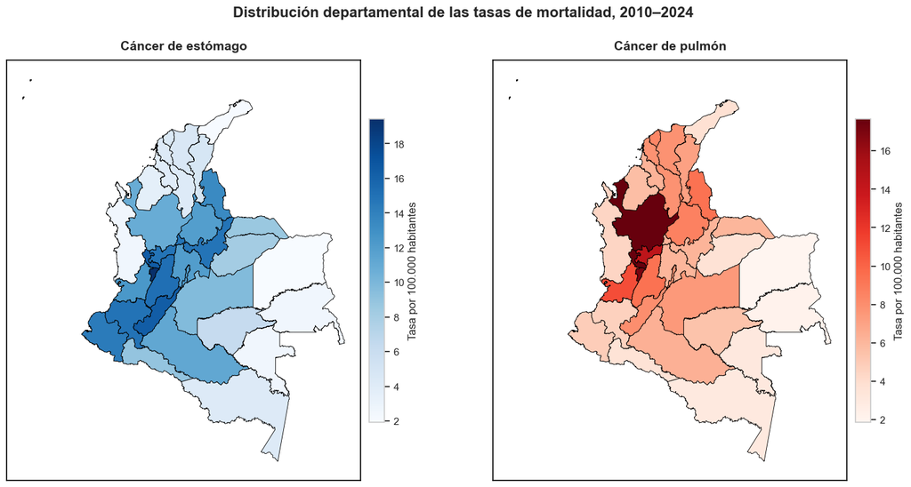

```python
mapa_tasas = geo_departamentos.merge(
    tasas_departamentales[
        ["CODPTORE", "Tasa_estomago", "Tasa_pulmon"]
    ],
    on="CODPTORE",
    how="left"
)

fig, axes = plt.subplots(1, 2, figsize=(15, 8))

configuraciones = [
    ("Tasa_estomago", "Cáncer de estómago", "Blues"),
    ("Tasa_pulmon", "Cáncer de pulmón", "Reds")
]

for ax, (columna, titulo, cmap) in zip(axes, configuraciones):
    mapa_tasas.plot(
        column=columna,
        ax=ax,
        cmap=cmap,
        edgecolor="black",
        linewidth=0.6,
        legend=True,
        legend_kwds={
            "label": "Tasa por 100.000 habitantes",
            "shrink": 0.70,
            "pad": 0.02
        }
    )

    ax.set_title(
        titulo,
        fontsize=14,
        fontweight="bold",
        pad=12
    )

    ax.set_xticks([])
    ax.set_yticks([])
    ax.set_xlabel("")
    ax.set_ylabel("")

    for spine in ax.spines.values():
        spine.set_visible(True)
        spine.set_color("black")
        spine.set_linewidth(1.2)

fig.suptitle(
    "Distribución departamental de las tasas de mortalidad, 2010–2024",
    fontsize=16,
    fontweight="bold",
    y=0.97
)

plt.subplots_adjust(
    left=0.04,
    right=0.96,
    bottom=0.06,
    top=0.88,
    wspace=0.14
)

plt.show()
```

Al considerar el tamaño de la población, la distribución territorial cambia frente a la observada con los conteos absolutos. En cáncer de estómago, las tasas más altas se concentran principalmente en departamentos de la región Andina, destacándose Quindío, Risaralda, Huila, Tolima, Cauca y Caldas. Quindío presenta la tasa más alta del periodo, con 19.44 muertes por cada 100.000 habitantes.

Para cáncer de pulmón se observa una concentración particularmente alta en Antioquia, Risaralda y Quindío, mientras que otros departamentos presentan tasas considerablemente menores. Antioquia registra la tasa más alta, con 17.67 muertes por cada 100.000 habitantes, seguida muy de cerca por Risaralda con 17.66.

La comparación con los mapas de conteos absolutos muestra la importancia de considerar el tamaño de la población. Bogotá D.C., por ejemplo, concentraba una gran cantidad de registros, especialmente para cáncer de estómago, pero no se encuentra entre los departamentos con las tasas más altas. Por otro lado, departamentos con poblaciones menores, como Quindío y Risaralda, adquieren mayor relevancia al analizar las defunciones en relación con su población.

### 4.5 Mortalidad según sexo

El análisis inicial de los registros mostró una mayor cantidad de defunciones en hombres para ambos tipos de cáncer. Sin embargo, los conteos por sí solos no permiten determinar si esta diferencia se mantiene al considerar el tamaño de la población masculina y femenina.

Para realizar esta comparación, se calculan tasas de mortalidad por sexo utilizando las defunciones registradas y la población correspondiente a hombres y mujeres durante el periodo 2010–2024. Las tasas se expresan como el número de defunciones por cada 100.000 habitantes del mismo sexo.

#### 4.5.1 Evolución anual de las tasas de mortalidad según sexo

Para comparar la mortalidad entre hombres y mujeres, se relacionan las defunciones registradas cada año con la población del mismo sexo. De esta forma, se obtienen tasas anuales por cada 100.000 hombres y por cada 100.000 mujeres, evitando que las diferencias en el tamaño de ambas poblaciones afecten directamente la comparación.

Las tasas obtenidas permiten comparar directamente la mortalidad entre hombres y mujeres. A continuación se presentan los valores anuales calculados para ambos tipos de cáncer durante el periodo analizado.

```python
tabla_tasas_sexo = tasas_sexo_anuales[
    [
        "ANO",
        "Tasa_estomago_hombres",
        "Tasa_estomago_mujeres",
        "Tasa_pulmon_hombres",
        "Tasa_pulmon_mujeres"
    ]
].copy()

tabla_tasas_sexo.columns = [
    "Año",
    "Estómago - Hombres",
    "Estómago - Mujeres",
    "Pulmón - Hombres",
    "Pulmón - Mujeres"
]

tabla_tasas_sexo.style.format({
    "Estómago - Hombres": "{:.2f}",
    "Estómago - Mujeres": "{:.2f}",
    "Pulmón - Hombres": "{:.2f}",
    "Pulmón - Mujeres": "{:.2f}"
}).set_table_styles([
    {
        "selector": "",
        "props": [
            ("margin-left", "auto"),
            ("margin-right", "auto"),
            ("border-collapse", "collapse")
        ]
    },
    {
        "selector": "th",
        "props": [
            ("background-color", "white"),
            ("color", "black"),
            ("font-weight", "bold"),
            ("text-align", "center"),
            ("padding", "10px"),
            ("border", "1px solid black")
        ]
    },
    {
        "selector": "td",
        "props": [
            ("text-align", "center"),
            ("padding", "8px"),
            ("border", "1px solid black")
        ]
    }
]).hide(axis="index")
```

| Año | Estómago - Hombres | Estómago - Mujeres | Pulmón - Hombres | Pulmón - Mujeres |
| --- | --- | --- | --- | --- |
| 2010 | 12.99 | 7.65 | 11.00 | 7.20 |
| 2011 | 12.75 | 7.60 | 10.88 | 6.99 |
| 2012 | 12.75 | 8.01 | 10.58 | 7.51 |
| 2013 | 13.53 | 7.79 | 11.28 | 7.27 |
| 2014 | 13.61 | 8.43 | 11.66 | 7.92 |
| 2015 | 13.83 | 8.36 | 11.70 | 8.38 |
| 2016 | 13.58 | 8.26 | 11.83 | 8.13 |
| 2017 | 13.80 | 8.25 | 12.02 | 8.29 |
| 2018 | 13.81 | 8.43 | 11.29 | 8.39 |
| 2019 | 13.51 | 8.65 | 10.83 | 7.60 |
| 2020 | 12.96 | 7.94 | 11.06 | 7.44 |
| 2021 | 12.84 | 8.11 | 9.57 | 7.37 |
| 2022 | 12.54 | 7.92 | 9.78 | 7.61 |
| 2023 | 12.40 | 8.08 | 10.45 | 7.88 |
| 2024 | 12.44 | 7.70 | 10.67 | 8.18 |

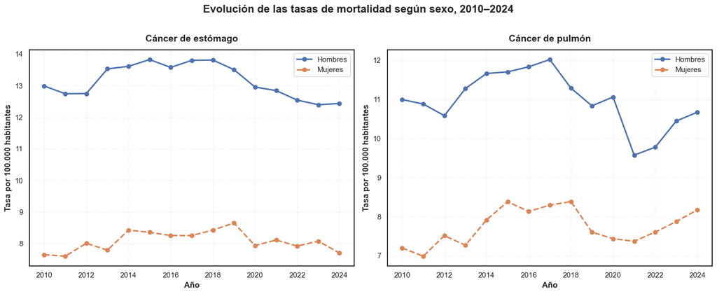

```python
tasas_sexo_anuales = tasas_sexo_anuales[
    tasas_sexo_anuales["ANO"].between(2010, 2024)
].copy()

fig, axes = plt.subplots(1, 2, figsize=(15, 6))

axes[0].plot(
    tasas_sexo_anuales["ANO"],
    tasas_sexo_anuales["Tasa_estomago_hombres"],
    marker="o",
    linewidth=2.2,
    label="Hombres"
)

axes[0].plot(
    tasas_sexo_anuales["ANO"],
    tasas_sexo_anuales["Tasa_estomago_mujeres"],
    marker="o",
    linewidth=2.2,
    linestyle="--",
    label="Mujeres"
)

axes[1].plot(
    tasas_sexo_anuales["ANO"],
    tasas_sexo_anuales["Tasa_pulmon_hombres"],
    marker="o",
    linewidth=2.2,
    label="Hombres"
)

axes[1].plot(
    tasas_sexo_anuales["ANO"],
    tasas_sexo_anuales["Tasa_pulmon_mujeres"],
    marker="o",
    linewidth=2.2,
    linestyle="--",
    label="Mujeres"
)

titulos = ["Cáncer de estómago", "Cáncer de pulmón"]

for ax, titulo in zip(axes, titulos):
    ax.set_title(titulo, fontsize=14, fontweight="bold", pad=12)
    ax.set_xlabel("Año", fontweight="bold")
    ax.set_ylabel("Tasa por 100.000 habitantes", fontweight="bold")
    ax.set_xticks(range(2010, 2025, 2))
    ax.grid(True, linestyle="--", alpha=0.25)
    ax.legend(frameon=True)

    for spine in ax.spines.values():
        spine.set_visible(True)
        spine.set_color("black")
        spine.set_linewidth(1.2)

fig.suptitle(
    "Evolución de las tasas de mortalidad según sexo, 2010–2024",
    fontsize=16,
    fontweight="bold",
    y=1.01
)

plt.tight_layout()
plt.show()
```

Las tasas de mortalidad son mayores en los hombres durante todo el periodo analizado para ambos tipos de cáncer. En cáncer de estómago, la diferencia entre hombres y mujeres se mantiene de forma clara entre 2010 y 2024. La tasa masculina alcanza sus valores más altos entre 2014 y 2018 y posteriormente presenta una disminución, mientras que la tasa femenina se mantiene más estable a lo largo del periodo.

En cáncer de pulmón también se observa una tasa de mortalidad masculina superior durante todos los años. En los hombres, la tasa aumenta hasta alcanzar su valor más alto en 2017 y posteriormente disminuye, con una caída más marcada en 2021. Desde 2022 se observa nuevamente un aumento. En las mujeres, aunque las tasas son menores, se presenta un incremento durante varios de los primeros años y nuevamente entre 2021 y 2024.

Estos resultados confirman que la mayor cantidad de defunciones masculinas observada inicialmente no se debe únicamente a diferencias en el tamaño de las poblaciones. Incluso al relacionar las defunciones con la población de cada sexo, los hombres presentan tasas de mortalidad superiores para ambos tipos de cáncer durante todo el periodo estudiado.